# Assignment 2

Hari Subhash

Date created: 2019-05-05

**Due Date**: Sunday, April 28th

**Keyboard Shortcuts**:

1. Assignment operator (<-) is `Alt+-` for Windows and `Option+-` for Mac
2. Insert new code chunk `Ctrl+Alt+I` for Windows and `Command+Option+I` for Mac
3. Run a line of code `Ctrl+Enter` for Windows and `Command+Enter` for Mac
4. Run all the code within a chunk `Ctrl+Shift+Enter` for Windows and `Command+Shift+Enter` for Mac
5. Insert a pipe operator (%>%) `Ctrl+Shift+M` for Windows and `Command+Shift+M` for Mac

**General Instructions**

1. Create a new notebook (copy parts of the YAML header you are interested in keeping) to work on your assignment.
2. The assignment should be submitted via a shareable github link that points to your notebook (.nb.html) file to me on Slack.
3. Make sure the notebook is neatly formatted, and that all the charts and tables and look good when you preview it.

**Task**: Explore at least 5 different causes for departure and arrival delays (combined - not 5 each). Its not necessary that you find a definitive answer for what causes a delay, instead I want you to showcase your ability to explore the data with a combination of analytical text, tables and charts. The final output should be something you can show a prospective employer or client as proof of you ability to work with data in R.

## Let’s talk game plan.

I want to try: distance, month, dest, precip, temp, visib for all of these, I may want to split by origin. My graph options include histogram, geom_point (scatter), geom_jitter, geom_smooth(method=lm), geom_line for line chart, geom_col for discrete x continuous y, geom_boxplot, geom_count and for one var, geom_hist, geom_density, geom_dotplot.

** Important notes you have never got re summarise. Group by the “background” vars you want to see compared to your dependent var. use the summarize command to perform functions on the dependent var. Don’t group by the dependent var**

*Section One First hypothesis: Distance and arrival delay, let’s see if there is a relationship. REMAINDERS: Charts A-3 and A-5 have wasted space in some of the origin facets. REMAINDERS: What we found would make it interesting to check dep_delay and Distance.

A-1: Let’s look at the data.

```r
  unique(flights$arr_delay)
```

[output not shown]

```r
  unique(flights$distance)
```

```
  [1] 1400 1416 1089 1576  762  719 1065  229  944  733 1028 1005 2475 2565 1389  187 2227 1076 1023 1020  502 1085  760 2586
 [25] 1074 1598  746 2133 1096 1008 2153 2454  185  529  212  950  301 1620 2434 2248 1182 1035 1990 1147  997 1069 1068 1608
 [49]  738 2402 1372 1605  264 1080  937  209 1010 1041 2422  544  427  200  541  479  820 1029  628  946  340 2446  213  419
 [73]  888  828  740  550  431  509  184 1874  416  488 2425  711 4983  764 1521  266   96 1623 1634  404  228 1726  199  725
 [97] 1047  583  273  872  282  645  284  214  708  397  195  463  246  169 1428 1183 2465  533 1411  143  116 1969  319 4963
[121]  799  445  963  569  425 1504  277  665  292  483  594  605 1092  765 1391  589  335  748   94 1107 1626 1747  290 1569
[145]  642 2569 1134  636  444 2576 2521 1585 1215 1587  631 1325  160 1017 1617  585 1131  618  254  964  647  866  269 1167
[169]  602  288   80 1728 1882 1795 1207 2378  461  833  258  641  722  659  660  549  378  812  296 1417 1113 1148 1031  610
[193] 1826  500  198  173  651  892  604  637 1725 1746  617 1894  662  305  745  599  865  655  563  644 3370   17
```

```r
flights %>%
  group_by(distance, origin) %>%
  summarise(meandelayQ101 = mean(arr_delay, na.rm = T)) %>%
  arrange(distance)
```

| distance | origin | meandelayQ101 |
| --- | --- | --- |
| 17 | EWR | NaN |
| 80 | EWR | 16.5416667 |
| 94 | JFK | 12.6882682 |
| 96 | LGA | 5.7792642 |
| 116 | EWR | 7.0485437 |
| 143 | EWR | 14.3971292 |
| 160 | EWR | 16.2346369 |
| 169 | EWR | 15.0763359 |
| 173 | JFK | -0.2857143 |
| 184 | JFK | 8.9843206 |

[output cut: 212 more lines]

Nothing too obvious here. A-2: Let’s check out distance outliers.

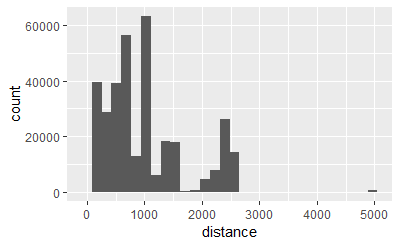

```r
flights %>%
  ggplot(aes(x = distance)) +
  geom_histogram()
```

There are some.

A-3 - Let’s facet by origin for our first major two-variable graph.

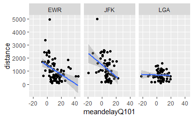

```r
flights %>%
  group_by(distance, origin) %>%
  summarise(meandelayQ101 = mean(arr_delay, na.rm = T)) %>%
  arrange(distance) %>%
  ggplot(aes(x = meandelayQ101, y = distance)) +
  geom_point() +
  geom_smooth(method = lm) +
  facet_wrap(~ origin)
```

It looks like distance falls as arrival delay increases, except at LaGuardia. A little weird. The segmentation of origin I did is a bit random.

A-4: Does the relationship hold across the combined airports?

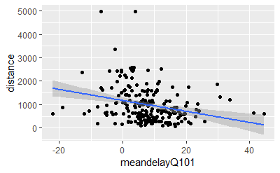

```r
flights %>%
  group_by(distance, origin) %>%
  summarise(meandelayQ101 = mean(arr_delay, na.rm = T)) %>%
  arrange(distance) %>%
  ggplot(aes(x = meandelayQ101, y = distance)) +
  geom_point() +
  geom_smooth(method = lm)
```

It does. A-5: Let’s try minus outlier distances.

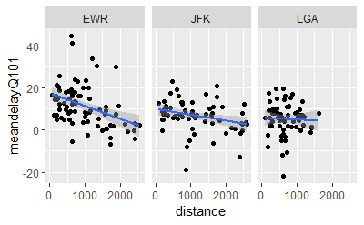

```r
flights %>%
  group_by(distance, origin) %>%
  filter(distance < 3000) %>%
  summarise(meandelayQ101 = mean(arr_delay, na.rm = T)) %>%
  arrange(distance) %>%
  ggplot(aes(x = distance, y = meandelayQ101)) +
  geom_point() +
  geom_smooth(method = lm) +
  facet_wrap(~ origin)
```

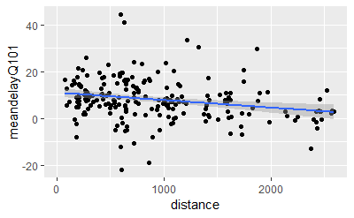

```r
flights %>%
  group_by(distance, origin) %>%
  filter(distance < 3000) %>%
  summarise(meandelayQ101 = mean(arr_delay, na.rm = T)) %>%
  arrange(distance) %>%
  ggplot(aes(x = distance, y = meandelayQ101)) +
  geom_point() +
  geom_smooth(method = lm)
```

There is a trend here.

*SECTION TWO Hypothesis Two: there is a relationship between Precip in weather and Departure Delay. (Spends a full hour understanding joins again) B-1: Let’s make our dataset. Right now, Precip and flights are separated.

```r
weather
```

| origin | year | month | day | hour | temp | dewp | humid | wind_dir | wind_speed | wind_gust | precip | pressure | visib | time_hour |
| --- | --- | --- | --- | --- | --- | --- | --- | --- | --- | --- | --- | --- | --- | --- |
| EWR | 2013 | 1 | 1 | 1 | 39.02 | 26.06 | 59.37 | 270 | 10.35702 | NA | 0.00 | 1012.0 | 10.00 | 2013-01-01 01:00:00 |
| EWR | 2013 | 1 | 1 | 2 | 39.02 | 26.96 | 61.63 | 250 | 8.05546 | NA | 0.00 | 1012.3 | 10.00 | 2013-01-01 02:00:00 |
| EWR | 2013 | 1 | 1 | 3 | 39.02 | 28.04 | 64.43 | 240 | 11.50780 | NA | 0.00 | 1012.5 | 10.00 | 2013-01-01 03:00:00 |
| EWR | 2013 | 1 | 1 | 4 | 39.92 | 28.04 | 62.21 | 250 | 12.65858 | NA | 0.00 | 1012.2 | 10.00 | 2013-01-01 04:00:00 |
| EWR | 2013 | 1 | 1 | 5 | 39.02 | 28.04 | 64.43 | 260 | 12.65858 | NA | 0.00 | 1011.9 | 10.00 | 2013-01-01 05:00:00 |
| EWR | 2013 | 1 | 1 | 6 | 37.94 | 28.04 | 67.21 | 240 | 11.50780 | NA | 0.00 | 1012.4 | 10.00 | 2013-01-01 06:00:00 |
| EWR | 2013 | 1 | 1 | 7 | 39.02 | 28.04 | 64.43 | 240 | 14.96014 | NA | 0.00 | 1012.2 | 10.00 | 2013-01-01 07:00:00 |
| EWR | 2013 | 1 | 1 | 8 | 39.92 | 28.04 | 62.21 | 250 | 10.35702 | NA | 0.00 | 1012.2 | 10.00 | 2013-01-01 08:00:00 |
| EWR | 2013 | 1 | 1 | 9 | 39.92 | 28.04 | 62.21 | 260 | 14.96014 | NA | 0.00 | 1012.7 | 10.00 | 2013-01-01 09:00:00 |
| EWR | 2013 | 1 | 1 | 10 | 41.00 | 28.04 | 59.65 | 260 | 13.80936 | NA | 0.00 | 1012.4 | 10.00 | 2013-01-01 10:00:00 |

[output cut: 990 more lines]

```r
Preciptest <- flights %>%
  select(time_hour, origin, dep_delay) %>%
  left_join(
    x = .,
    y = weather,
    by = c("origin", "time_hour"))
```

[output not shown]